# Analyse et Prévision d'une série chronologiques avec Python

> **Travail réalisé par :**
> - [Isbaine Mohamed](https://github.com/isbainemohamed)
> - [Labriji Saad](https://github.com/labrijisaad)

> **Travail encadré par :**
> - fadoua badaoui

### Voici les différentes parties développées pour l'analyse de notre série chronologique :

#### Partie 1 : `Premier contact et préparation de notre dataframe.`

#### Partie 2 : `Composants de notre série chronologique.`

#### Partie 3 : `Etude des composantes de la série.`

#### Partie 4 : `Etude de l'autocorrélation de notre série chronologique.`

#### Partie 5 : `Estimation de notre modèle AR.`

> > Prédiction avec **ARIMA**  
> > Prédiction avec **ARIMAX**  
> > Prédiction avec **ARMA**  
> > Conclusion.

## Partie 1 : Premier contact et préparation de notre dataframe :

> Dans cette partie, nous allons tout d'abord passer en revue l'importation de notre série temporelle choisie (`lien de la série chronologique ➡`[ICI](https://www.ncdc.noaa.gov/cag/city/time-series/USH00300042-tavg-all-1-1895-2021.csv?base_prd=true&begbaseyear=1930&endbaseyear=2000)) avec python dans une dataframe pandas (`pandas's dataframe` est la structure de données la plus appropriée pour travailler avec des séries temporelles). Nous inspecterons ensuite la dataframe à la recherche de valeurs manquantes, modifierons les noms de colonne si nécessaire, convertirons la colonne de date en `datetime` (datetime est le type utilisé pour les entrées qui composent un DatetimeIndex et d'autres structures de données orientées séries temporelles dans les pandas), et définirons l'index des dataframes. Nous allons ensuite fournir les statistiques descriptives (résumées), tracer la série temporelle, afficher la fréquence des données avec un histogramme et montrer la distribution des données, en utilisant un graphique de densité de noyau. Enfin, nous allons enregistrer la nouvelle serie chronologique dans un nouvel fichier.

> Voici les bibliothèques que nous utilisons dans cette partie :

```python
import pandas as pd
import numpy as np
import matplotlib.pyplot as plt
```

> Après avoir téléchargé le fichier csv, nous l'importons avec la fonction **`.read()`** de la librairie pandas.

```python
temperature_dataframe = pd.read_csv("C:\\Users\\SAAD\\Desktop\\USH00300042-tavg-all-1-1895-2021(1).csv", skiprows=4,
                                    infer_datetime_format=True)
temperature_dataframe.head()
```

|  | Date | Value | Anomaly |
| --- | --- | --- | --- |
| 0 | 189501 | 20.6 | -1.6 |
| 1 | 189502 | 17.0 | -7.3 |
| 2 | 189503 | 27.9 | -6.2 |
| 3 | 189504 | 45.1 | -1.4 |
| 4 | 189505 | 59.6 | 1.5 |

> Le résultat de la fonction **`.head()`** nous montre les 5 premières lignes de notre `dataframe` **( c'est pour avoir de la visibilité sur la structure générale du dataframe )**.

> Déjà, des modifications essentielles nous sautent aux yeux :
> - `Changer le type de données` de la colonne Date,
> - `Indexer notre data frame` avec la colonne Date,
> - `Réduire notre dataframe` à seulement 2 colonnes : Date, Value **(cela suffit pour notre étude)**.

```python
temperature_dataframe.describe()
```

|  | Date | Value | Anomaly |
| --- | --- | --- | --- |
| count | 1513.000000 | 1513.000000 | 1513.000000 |
| mean | 195760.693325 | 47.421084 | -0.262062 |
| std | 3640.849232 | 18.892171 | 6.937443 |
| min | 189501.000000 | -99.000000 | -138.500000 |
| 25% | 192607.000000 | 31.600000 | -2.200000 |
| 50% | 195801.000000 | 48.800000 | 0.000000 |
| 75% | 198907.000000 | 64.600000 | 2.100000 |
| max | 202101.000000 | 76.700000 | 14.600000 |

> Le résultat de la fonction **`.describe()`** nous montre les statistiques descriptives de notre dataframe. puisque la colonne Valeur a un minimum de -99,0 ° F, cela signifie qu'il manque des données dans la trame de données. Notre prochain objectif est de localiser ces valeurs manquantes, puis de les remplacer par des valeurs réalistes à l'aide de la fonction d'interpolation **`.interpolate()`** de la bibliothèque pandas.

```python
# Conversion du type de données de la colonne Date en datetime.
temperature_dataframe['Date'] = pd.to_datetime(temperature_dataframe['Date'], format='%Y%m')
```

```python
# Définition de l'index du dataframe en tant que colonne Date.
temperature_dataframe.set_index('Date', inplace=True)
temperature_dataframe.head()
```

| Date | Value | Anomaly |
| --- | --- | --- |
| 1895-01-01 | 20.6 | -1.6 |
| 1895-02-01 | 17.0 | -7.3 |
| 1895-03-01 | 27.9 | -6.2 |
| 1895-04-01 | 45.1 | -1.4 |
| 1895-05-01 | 59.6 | 1.5 |

> Nous réaffichons les 5 premières lignes pour voir les résultats des modifications effectuées.

```python
# Réduction du dataframe à un nouveau qui contient les colonnes qui nous intéressent pour cette étude.
temperature_dataframe = temperature_dataframe[['Value']]
```

> **Notez que** jusqu'à cette étape, `nous n'avons pas traité les valeurs manquantes`. `Nous voulons d'abord tracer la série chronologique avec les valeurs manquantes` pour voir l'effet des valeurs manquantes sur l'étude.

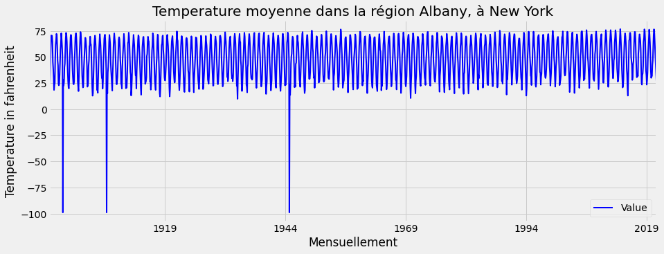

```python
# On trace la série chronologique sans valeurs manquantes :

plt.style.use('fivethirtyeight')  # On utilise un style de graphe prédéfinie dans la linrary matplotlib
figure = temperature_dataframe.plot(color='blue', grid=True, figsize=(14, 5), linewidth=2)
figure.set_xlabel('Mensuellement')
figure.set_ylabel('Temperature in fahrenheit')
figure.set_title('Temperature moyenne dans la région Albany, à New York')
plt.show()
```

> **Remarque**: On peut constater l'effet des valeurs manquantes sur la représentation graphique de la série. On a zones où la courbe descend jusqu'à la valeur -99.0.

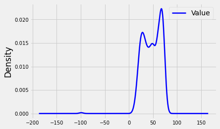

```python
# On trace la courbe de densité de nos données :

temperature_dataframe.plot(kind='density', color="blue", grid=True, linewidth=2.5, fontsize=10)
```

**Interplation des données :**

> D'abord nous alons localiser les valeurs manquantes, pour les remplacer par des valeurs réalistes à l'aide de la fonction d'interpolation `.interpolate()` de la bibliothèque pandas.

> La fonction `.interpolate()` est essentiellement utilisée pour *remplir les valeurs NA dans la trame de données ou la série*. Mais, c'est une fonction très puissante pour remplir les valeurs manquantes. *Il utilise diverses techniques d'interpolation* pour remplir les valeurs manquantes plutôt que de coder en dur la valeur.

```python
# Requête pour trouver la valeur manquante attribuée à -99.0, qui détermine la position de l'index :
Index_positions = temperature_dataframe.query('Value == -99.0').index.tolist()

# On récupère la liste des lignes où il y a des valeurs manquantes :
Index_positions
```

```
[Timestamp('1897-11-01 00:00:00'),
 Timestamp('1906-12-01 00:00:00'),
 Timestamp('1944-11-01 00:00:00')]
```

> On met des **NaN** au lieu de **-99.0**, nous utilisons **`numpy.nan`**  
> **NB:** La raison pour avoir remplacé les valeurs manquantes par NaN est que la fonction d'interpolation que nous allons utiliser ne reconnaîtra les valeurs manquantes que par Nan

```python
for index in Index_positions:
    # On affiche la valeur pour s'assurer qu'il s'agit bien d'une valeur égale à -99.0
    print(temperature_dataframe.at[index, 'Value'])
    temperature_dataframe.at[index, 'Value'] = np.nan
```

```
-99.0
-99.0
-99.0
```

```python
# Maintenant, nous vérifions le nombre de nan (c'est le nombre de valeurs manquantes)

temperature_dataframe.isna().sum()
```

```
Value    3
dtype: int64
```

> Comme prévu, le nombre de NaN est égal à 3 ( le graphique dans le nom : `Temperature moyenne dans la région Albany, à New York` montre qu'il y a 3 valeur qui sont égales à -99,0 )

> **Définition**: `L'interpolation linéaire` est une méthode d'ajustement de courbe utilisant des polynômes linéaires pour construire de nouveaux points de données dans la plage d'un ensemble discret de points de données connus.

```python
# Utilisons maintenant la méthode d'interpolation linéaire pour mettre une valeur à la place de Nan.
# On utilise l'interpolation linéaire.
# L'option limit_direction permet de spécifier la direction de remplissage des NaN consécutifs.

temperature_dataframe = temperature_dataframe.interpolate(method ='linear', limit_direction ='forward')
```

```python
# On vérifie que les valeurs égales à NaN ( dans notre cas une seule valeur ) ont bien été remplacées par des nombres réels.

for index in Index_positions:
    print(temperature_dataframe.at[index, 'Value'])

temperature_dataframe.describe()
```

```
39.55
28.6
35.85
```

|  | Value |
| --- | --- |
| count | 1513.000000 |
| mean | 47.686120 |
| std | 17.738932 |
| min | 9.800000 |
| 25% | 31.700000 |
| 50% | 48.800000 |
| 75% | 64.600000 |
| max | 76.700000 |

> **On remarque que** `le minimum des valeurs de nos données n'est plus -99.0`, ce qui signifie qu'on a éliminé les valeurs manquantes et `on les a remplacé par :` **39.55**, **28.6** et **35.85**

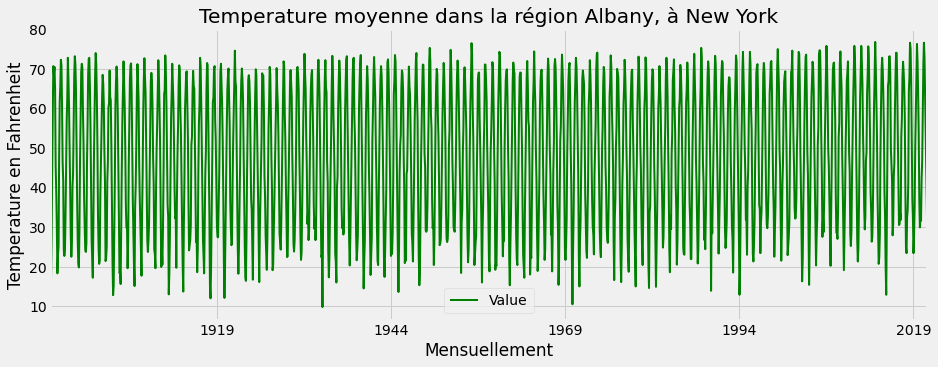

```python
# On trace la série chronologique : avec l'unité fahrenheit.

plt.style.use('fivethirtyeight')
figure = temperature_dataframe.plot(color='green', grid=True, figsize=(14,5), linewidth = 2)
figure.set_xlabel('Mensuellement')
figure.set_ylabel('Temperature en Fahrenheit')
figure.set_title('Temperature moyenne dans la région Albany, à New York')
plt.show()
```

> Enfin, le graphe est beau à voir, on peut dire que **notre dataframe est prêt à être utilisé**.

> Voici la formule qui permet de passer du `fahrenheit` au `celsius` : $$ C = \frac{5}{9} * (F-32) $$

```python
temperature_dataframe_copy = temperature_dataframe.copy()  # On fait un copie pour ne pas changer notre dataframe.

# On ajoute une colonne pour les température en Celesius :
temperature_dataframe_copy['Value in celsius'] = temperature_dataframe_copy['Value'].apply(
                                                    lambda x: 5 * x / 9 - 5 * 32 / 9)

temperature_dataframe_copy = temperature_dataframe_copy.rename(columns={"Date": "Date",
                                                                        "Value": "Value in fahrenheit",
                                                                        "Value_in_celsius": "Value in celsius"})
temperature_dataframe_copy.head()
```

| Date | Value in fahrenheit | Value in celsius |
| --- | --- | --- |
| 1895-01-01 | 20.6 | -6.333333 |
| 1895-02-01 | 17.0 | -8.333333 |
| 1895-03-01 | 27.9 | -2.277778 |
| 1895-04-01 | 45.1 | 7.277778 |
| 1895-05-01 | 59.6 | 15.333333 |

```python
temperature_dataframe_copy.describe()
```

|  | Value in fahrenheit | Value in celsius |
| --- | --- | --- |
| count | 1513.000000 | 1513.000000 |
| mean | 47.686120 | 8.714511 |
| std | 17.738932 | 9.854962 |
| min | 9.800000 | -12.333333 |
| 25% | 31.700000 | -0.166667 |
| 50% | 48.800000 | 9.333333 |
| 75% | 64.600000 | 18.111111 |
| max | 76.700000 | 24.833333 |

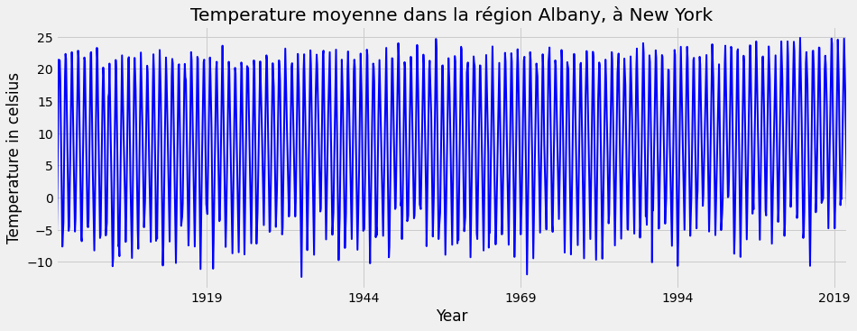

```python
# On trace la série chronologique : avec l'unité celsius.

plt.style.use('fast')
figure = temperature_dataframe_copy['Value in celsius'].plot(color="blue", grid=True, figsize=(14,5), linewidth = 2)
figure.set_xlabel('Year')
figure.set_ylabel('Temperature in celsius')
figure.set_title('Temperature moyenne dans la région Albany, à New York')
plt.show()
```

### Graphique de densité :

> Un `diagramme de densité` montre la distribution des données sur un intervalle continu.  
> Les pics d'un diagramme de densité aident à afficher où les valeurs sont concentrées sur l'intervalle.

> Un graphique de densité de noyau est une meilleure façon d'afficher la distribution car il n'est pas affecté par le nombre de bacs utilisés (chaque barre utilisée dans un histogramme typique).

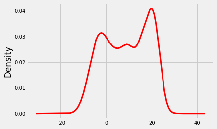

```python
# On Affiche  le graphique de densité :

temperature_dataframe_copy['Value in celsius'].plot(kind='density', color="red", grid=True, linewidth=3, fontsize=10)
```

### Histogramme de fréquence :

> `L'histogramme` est un outil fréquemment utilisé pour résumer des données discrètes ou continues qui sont présentées par intervalles de valeurs. Il est souvent employé pour montrer les caractéristiques principales de la distribution des données de façon pratique.

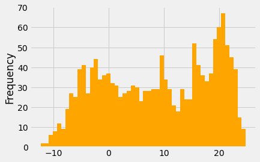

```python
temperature_dataframe_copy['Value in celsius'].plot(kind='hist', bins=50, color='orange', grid=True)
```

> On enregistre le dataframe dans un nouvel fichier csv ( **`Preprocessed_dataframe_temperature.csv`** )

```python
temperature_dataframe_copy['Value in celsius'].to_csv('Preprocessed_dataframe_temperature.csv')
```

> Après avoir nettoyé notre série temporelle, et après avoir substitué les valeurs manquantes. On procède pour diviser nos données en deux parties. Une partie comme echantillon d'entrainement du model et une autre echantillon pour le test des prévisions des données.  
> On a opté pour un pourcentage de **30% de données de test** et **70% de données d'entrainement**.

```python
# Nous importons le dataframe que nous venons de traiter.
dataframe_temperature_train = pd.read_csv("Preprocessed_dataframe_temperature.csv", parse_dates=['Date'], index_col=0,
                                          nrows=1050)

dataframe_temperature_test = pd.read_csv("Preprocessed_dataframe_temperature.csv", parse_dates=['Date'], index_col=0,
                                         skiprows=range(1, 1051))

# On affiche les tailles des deux echantillons train et test.
print("Taille des données Train:", dataframe_temperature_train.shape)
print("Taille des données Test:", dataframe_temperature_test.shape)
dataframe_temperature_train.to_csv('train-data.csv')
dataframe_temperature_test.to_csv('test-data.csv')
```

```
Taille des données Train: (1050, 1)
Taille des données Test: (463, 1)
```

## Partie 2 : composants de notre série chronologique :

### Composants d'une série chronologique :

> Une série chronologique se compose principalement de `tendance`, de `saisonnalité` et de `bruit`. Nous examinerons les composants de notre série temporelle, en nous concentrant sur les méthodes de décomposition automatisées.

#### `tendance`

> Lorsque nous parlons de tendance, nous parlons de la façon dont les données de la série augmentent ou diminuent au fil du temps. Se déplace-t-il vers le haut ou vers le bas au fil du temps ? La série est soit à la hausse, soit à la baisse, toutes deux non stationnaires.

#### `saisonnalité`

> La saisonnalité fait référence à un schéma périodique ou cyclique répétitif avec des intervalles réguliers au sein d'une série. Le modèle est dans une période de temps fixe et il se répète à intervalles réguliers. Il peut y avoir des oscillations vers le haut ou vers le bas, mais cela continue à se répéter sur une période de temps fixe, comme dans un cycle. La cyclicité peut se répéter mais elle n'a pas de période fixe.

#### `bruit`

> En général, le bruit capte les irrégularités ou la variation aléatoire de la série. Il peut avoir des événements erratiques ou simplement des variations aléatoires. Il a une courte durée. Il est difficile à prédire en raison de son apparition erratique.

```python
# Nous importons le dataframe que nous venons de traiter.

dataframe_temperature = pd.read_csv("train-data.csv", parse_dates=['Date'], index_col=0)
dataframe_temperature.shape
```

```
(1050, 1)
```

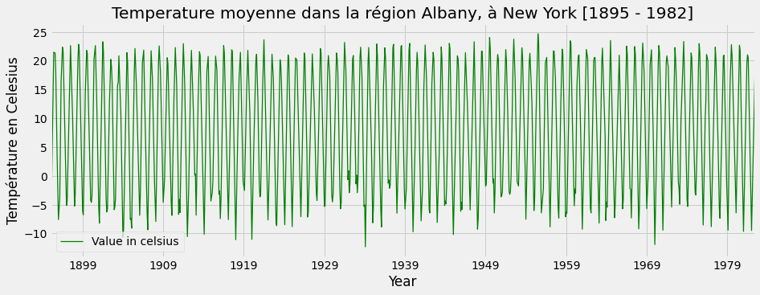

```python
# On trace la série chronologique :

plt.style.use('fast')
figure = dataframe_temperature.plot(color="green", grid=True, figsize=(14,5), linewidth = 1.25)
figure.set_xlabel('Year')
figure.set_ylabel('Température en Celesius')
figure.set_title('Temperature moyenne dans la région Albany, à New York [1895 - 1982]')
plt.show()
```

### Modélisation de séries chronologiques :

#### `Modèle additif :`

> Un modèle additif est `linéaire` : $$y(t) = Niveau + Tendance + Saisonnalité + Bruit$$ Elle est utile lorsque les variations autour de la tendance ne varient pas avec le niveau de la série temporelle. Les composants sont additionnés.

#### `Modèle multiplicatif :`

> Un modèle multiplicatif est `non-linéaire` : $$y(t) = Niveau * Tendance * Saisonnalité * Bruit$$ Une saisonnalité non linéaire a une fréquence et/ou une amplitude croissante ou décroissante dans le temps. Il est utile lorsque la tendance est proportionnelle au niveau de la série chronologique. Les composants sont multipliés ensemble.

> Voici les bibliothèques que nous utilisons dans cette partie :

```python
from statsmodels.tsa.seasonal import seasonal_decompose
import matplotlib.pyplot as plt
from pylab import rcParams
```

> Dans notre cas, notre série suit un modèle additif `linéaire` : $$Valeur = Niveau + Tendance + Saisonnalité + Bruit$$

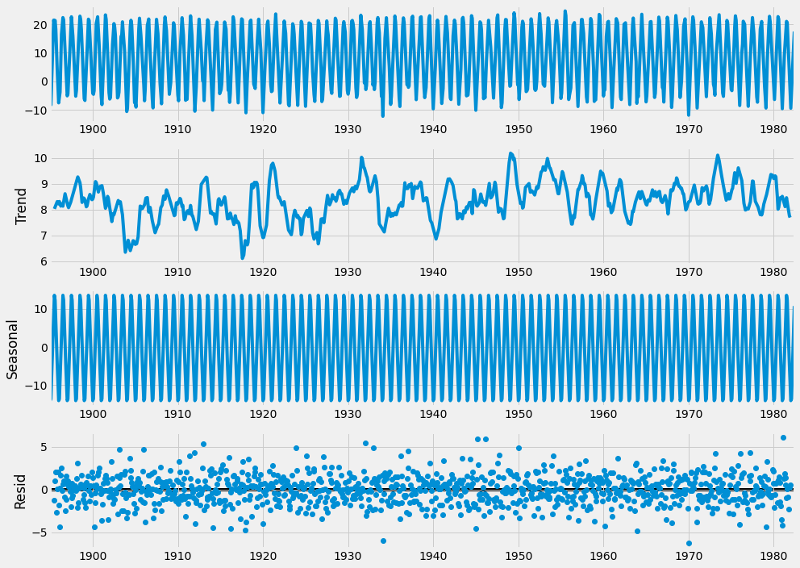

```python
rcParams['figure.figsize'] = 14, 10
plt.style.use('fivethirtyeight')
températures = dataframe_temperature

# period est le nombre de points de données dans un cycle répété.
result = seasonal_decompose(températures, model='additive', period=12)
result.plot()
plt.show()
```

> On a decomposé la série en trois composantes **`tendance`**, **`saisonnalité`** et **`bruit`**, on analysera maintenant chacune apart.

## **Partie 3: Etude des composantes de la série:**

#### `Etude de la Tendance:`

> Dans cette partie, on étudiera la `tendance`, en effectuant une `regression linéaire` sur celle-ci et donc en déduire la nature de la tendance ( ascendante, descendante exponentielle...)

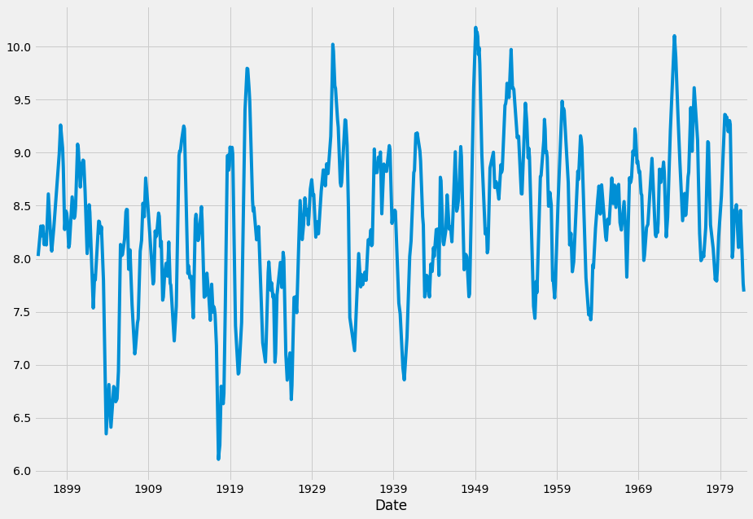

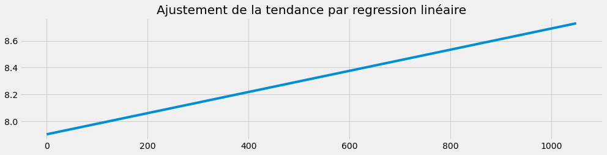

```python
# On importe la bibliothèque nécéssaire pour effectuer une régression linéaire.

from sklearn.linear_model import LinearRegression

result.trend.plot()
plt.show()
layout = (3, 2)
fit = plt.subplot2grid(layout, (2, 0), colspan=2)
X = [i for i in range(0, len(dataframe_temperature))]
X = np.reshape(X, (len(X), 1))
y = dataframe_temperature
model = LinearRegression()
model.fit(X, y)
trend = model.predict(X)
fit.plot(trend)
fit.set_title("Ajustement de la tendance par regression linéaire")
plt.tight_layout()
```

> D'après la figure ci-dessus, on remarque que **la série** a une **`tendance ascendante`**.

### Etude de la Saisonnalité:

##### `Détendre et désaisonnaliser une série temporelle :`

> Lors de la **suppression des tendances** et/ou de **l'ajustement de la saisonalité** d'une série chronologique, on peut utiliser une approche ou une combinaison d'approches telles que la `différenciation`, la `soustraction de la moyenne` (ou une moyenne sur une période), le calcul du changement en pourcentage ou l'utilisation d'une transformation telle qu'un transformation logarithmique. Par exemple, on prend la première différence puis une transformation logarithmique ou on peut utiliser une deuxième différence. Au fur et à mesure que l'on effectue diverses opérations (première différence, deuxième différence, soustraction de la moyenne, transformation logarithmique, variation en pourcentage), on obtient une certaine intuition sur la façon dont vos données changent.

> Il n'est pas toujours nécessaire de se détendre et de désaisonnaliser. cela peut ou non s'appliquer à nos données ou à votre domaine particulier. Parfois, on peut utiliser les données d'origine telles qu'elles sont.

##### `Différenciation :`

> La différenciation peut aider à réduire la tendance et la saisonnalité. On peut différencier nos données par soustraction. On soustracte la période précédente de la période actuelle.

##### `Soustraction de la moyenne :`

> On peut différencier nos données par soustraction. On soustrait la période précédente de la période actuelle.

```
[]
```

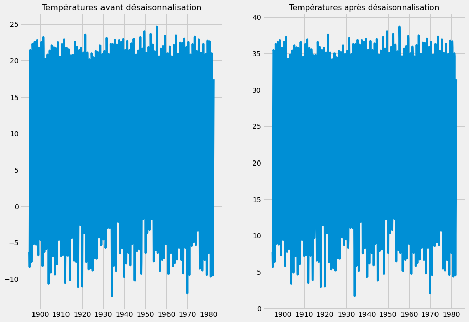

```python
dataframe_temperature.describe()

# Deseasonalize
deseasonalized = dataframe_temperature - result.seasonal[0]
deseasonalized.head()

plt.subplot(1, 2, 1)
plt.plot(dataframe_temperature)
plt.title('Températures avant désaisonnalisation', fontsize=16)
plt.plot()

plt.subplot(1, 2, 2)
plt.plot(deseasonalized)
plt.title('Températures après désaisonnalisation', fontsize=15)
plt.plot()
```

> La `désaisonnalisation` est une technique statistique qui tente de mesurer et de supprimer les influences des tendances saisonnières prévisibles pour révéler comment la température change d'une année à l'autre.

```python
dataframe_temperature.describe()
```

|  | Value in celsius |
| --- | --- |
| count | 1050.000000 |
| mean | 8.316825 |
| std | 9.944226 |
| min | -12.333333 |
| 25% | -1.041667 |
| 50% | 9.138889 |
| 75% | 17.722222 |
| max | 24.666667 |

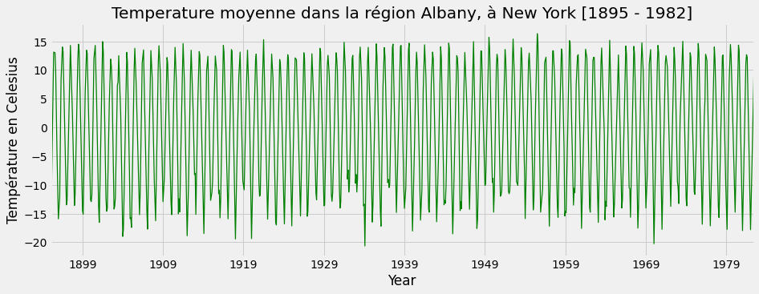

```python
dataframe_temperature['diff_mean'] = dataframe_temperature - dataframe_temperature.mean()
dataframe_temperature['diff_mean'].shape
plt.style.use('fast')
figure = dataframe_temperature['diff_mean'].plot(color="green", grid=True, figsize=(14,5), linewidth = 1.25)
figure.set_xlabel('Year')
figure.set_ylabel('Température en Celesius')
figure.set_title('Temperature moyenne dans la région Albany, à New York [1895 - 1982]')
plt.show()
```

```python
dataframe_temperature['diff_mean'].describe()
```

```
count    1.050000e+03
mean    -8.171241e-16
std      9.944226e+00
min     -2.065016e+01
25%     -9.358492e+00
50%      8.220635e-01
75%      9.405397e+00
max      1.634984e+01
Name: diff_mean, dtype: float64
```

[figure not shown]

```python
# On trace la série chronologique :

plt.style.use('fast')
figure = dataframe_temperature['diff_mean'].plot(color="blue", grid=True, figsize=(14,5), linewidth = 2)
figure.set_xlabel('Year')
figure.set_ylabel('Difference (Anomaly) from the Mean')
figure.set_title('Average temperature in °F of Sioux City, in Iowa')
```

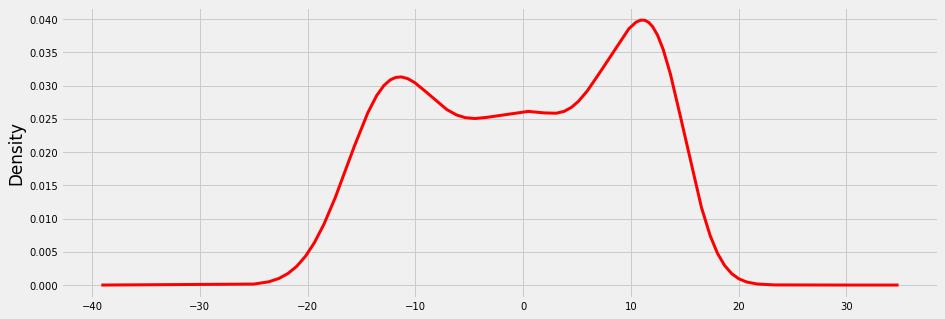

```python
# On Affiche  le graphique de densité :

dataframe_temperature['diff_mean'].plot(kind='density', color="red", figsize=(14, 5), grid=True, linewidth=3,
                                        fontsize=10)
```

#### Etudes de la `stationnarité` :

> La `stationnarité` est une caractéristique importante des `séries chronologiques`. Une série chronologique est stationnarité si elle a une moyenne et une variance constantes dans le temps. La plupart des modèles ne fonctionnent qu'avec des données stationnaires, car cela facilite la modélisation. Toutes les séries temporelles ne sont pas stationnaires, mais nous pouvons les transformer en séries stationnaires de différentes manières.

> Nous utiliserons le **`test de Dickey Fuller`** pour vérifier la stationnarité de nos données. Ce test générera des valeurs critiques et une p-value, ce qui nous permettra d'accepter ou de rejeter l'hypothèse nulle qu'il n'y a pas de stationnarité. Si nous rejetons l'hypothèse nulle, cela signifie que nous acceptons l'alternative, qui stipule qu'il y a stationnarité.

> Ces valeurs nous permettent de tester dans quelle mesure les valeurs actuelles changent avec les valeurs passées. S'il n'y a pas de stationnarité dans l'ensemble de données, un changement des valeurs actuelles n'entraînera pas de changement significatif des valeurs passées.

> Testons la **`stationnarité dans nos données`**. Pour commencer, calculons une moyenne mobile sur 1 an :

### `Un premier test de stationnarité` :

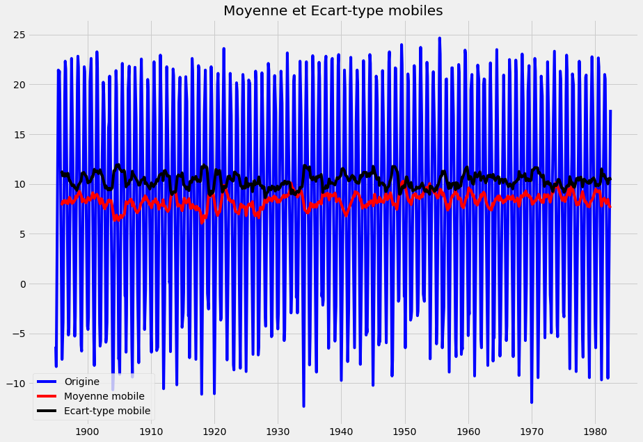

```python
dataframe_temperature1 = pd.read_csv("train-data.csv", parse_dates=['Date'], index_col=0)
rolling_mean = dataframe_temperature1.rolling(window = 12).mean()
rolling_std = dataframe_temperature1.rolling(window = 12).std()
plt.plot(dataframe_temperature1, color = 'blue', label = 'Origine')
plt.plot(rolling_mean, color = 'red', label = 'Moyenne mobile')
plt.plot(rolling_std, color = 'black', label = 'Ecart-type mobile')
plt.legend(loc = 'best')
plt.title('Moyenne et Ecart-type mobiles')
plt.show()
```

> Comme nous pouvons le voir, la moyenne mobile et l’écart-type mobile n'augmentent pas avec le temps. Nous pouvons donc conclure que **`la série temporelle est stationnaire`**.

### `Un deuxième test de stationnarité` :

```python
import pandas as pd
dataframe_temperature = pd.read_csv("train-data.csv", parse_dates=['Date'], index_col=0)

# On importe la bibliothèque nécéssaire pour effectuer le test de Dickey Fuller.

from statsmodels.tsa.stattools import adfuller
test_addfuller_result = adfuller(dataframe_temperature1, autolag="AIC")
output_df = pd.DataFrame({"Values": [test_addfuller_result[0], test_addfuller_result[1], test_addfuller_result[2],
                                     test_addfuller_result[3], test_addfuller_result[4]['1%'],
                                     test_addfuller_result[4]['5%'], test_addfuller_result[4]['10%']],
                          "Metric": ["Test Statistics", "p-value", "No. of lags used", "Number of observations used",
                                     "critical value (1%)", "critical value (5%)", "critical value (10%)"]})
print(output_df)
```

```
         Values                       Metric
0 -5.811586e+00              Test Statistics
1  4.388640e-07                      p-value
2  2.200000e+01             No. of lags used
3  1.027000e+03  Number of observations used
4 -3.436733e+00          critical value (1%)
5 -2.864358e+00          critical value (5%)
6 -2.568271e+00         critical value (10%)
```

## Partie 4 : Etude de l'autocorrélation de notre série chronologique :

### Corrélation et autocorrélation dans les séries chronologiques :

#### `Corrélation :`

> La `corrélation` est une mesure de la direction et de la force d'une relation. Dans ce cas, nous examinons deux séries temporelles. Les mesures vont de -1 à 1, 0 signifiant aucune relation ou corrélation nulle entre les deux séries. 1 signifie une corrélation positive parfaite et -1 signifie une corrélation négative parfaite. Les corrélations élevées sont vers 1 ou -1 tandis que les corrélations faibles sont vers 0. Dans les séries chronologiques, il faut être prudent lors de l'affichage de la corrélation, compte tenu de la période. Vous pouvez imaginer qu'un jour, il y a une corrélation forte et positive, mais que le lendemain, cela pourrait être une histoire différente sur la relation entre les deux séries.

#### `Autocorrélation :`

> Tout comme la corrélation, l'`autocorrélation` donne une mesure de la force et de la direction d'une relation entre deux séries temporelles. L'autocorrélation se fait avec une variable et son décalage. C'est une corrélation avec elle-même, donc une autocorrélation. Fondamentalement, vous utilisez la même série temporelle et créez une deuxième série, qui est décalée d'un pas de temps. Il est courant d'utiliser le tracé d'autocorrélation (ACF) pour visualiser l'autocorrélation d'une série chronologique. Commençons par examiner le bruit blanc.

#### `Bruit blanc :`

> Si votre série chronologique est statistiquement non corrélée (indépendante) avec une moyenne nulle et une variance constante, vous avez alors un type particulier de bruit appelé `bruit blanc`.

> Voici les bibliothèques que nous utilisons dans cette partie :

```python
from pandas.plotting import lag_plot
import numpy as np
import pandas as pd
import matplotlib.pyplot as plt
from statsmodels.graphics.tsaplots import plot_acf
from statsmodels.graphics.tsaplots import plot_pacf
```

```python
# Nous importons notre dataframe.

dataframe_temperature = pd.read_csv("Preprocessed_dataframe_temperature.csv", parse_dates=['Date'], index_col=0)
dataframe_temperature.head()
```

| Date | Value in celsius |
| --- | --- |
| 1895-01-01 | -6.333333 |
| 1895-02-01 | -8.333333 |
| 1895-03-01 | -2.277778 |
| 1895-04-01 | 7.277778 |
| 1895-05-01 | 15.333333 |

> Un graphique de décalage `lag plot` est utilisé pour aider à évaluer si les valeurs d'un ensemble de données ou d'une série chronologique sont aléatoires. Si les données sont aléatoires, le tracé de décalage ne présentera aucun motif identifiable. Si les données ne sont pas aléatoires, le tracé des décalages montrera un modèle clairement identifiable.

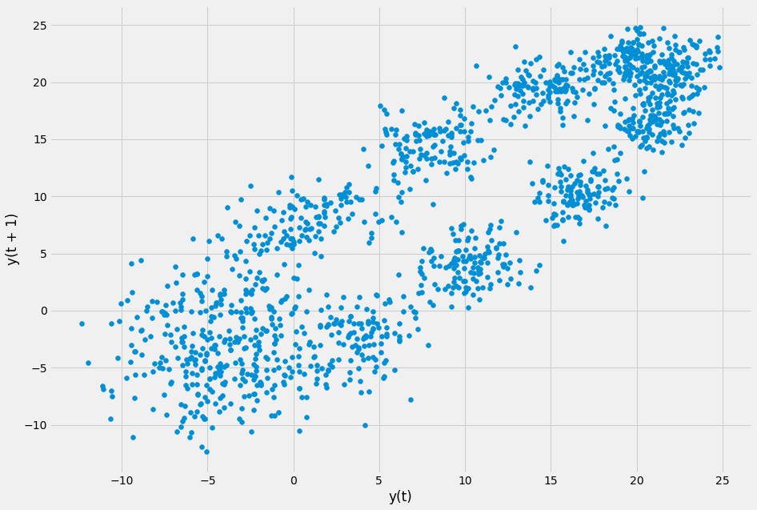

```python
# Lag Plot
lag_plot(dataframe_temperature)
plt.show()
```

> Le graphique ci-dessus montre `les données de temperature moyenne sur le` $y(t)$ `par rapport à son pas de temps précédent, le mois précédent, le` $y(t+1)$. De toute évidence, nous voyons une relation positive, bien qu'elle ait une plage de dispersion plus large.

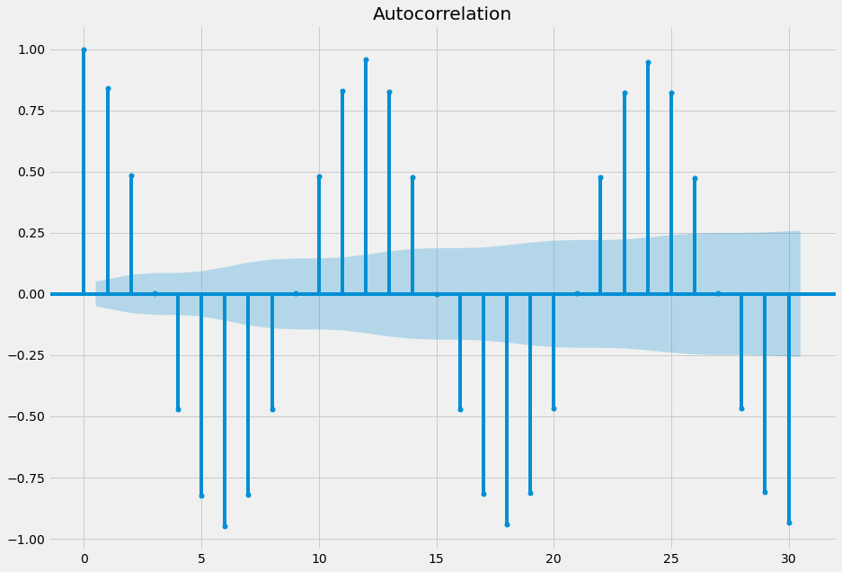

```python
# Nous traçons ACF pour visualiser l'autocorrélation :

from statsmodels.graphics.tsaplots import plot_acf
plot_acf(dataframe_temperature, lags=30)
plt.show()
```

> Un graphique ACF `ACF Plot` décrit à quel point la valeur actuelle de la série est liée à ses valeurs passées. Une série chronologique peut avoir des composants tels que tendance, saisonnalité, cyclique et résiduel. ACF prend en compte tous ces composants tout en trouvant des corrélations.

> La fonction d'autocorrélation partielle (PACF) donne la corrélation partielle d'une série chronologique avec ses propres valeurs décalées. Il contrôle les autres décalages. L'idée du PACF est que nous effectuons une corrélation entre une variable et elle-même décalée, puis nous soustrayons cet effet de la variable, puis découvrons quelle corrélation résiduelle reste de cette variable et d'autres décalages.

> Si les valeurs d'autocorrélation partielle sont proches de 0, les valeurs entre les observations et les observations décalées ne sont pas corrélées entre elles. Inversement, des autocorrélations partielles avec des valeurs proches de 1 ou -1 indiquent qu'il existe de fortes corrélations positives ou négatives entre les observations décalées de la série temporelle.

> La fonction `.plot_pacf()` renvoie également des intervalles de confiance, qui sont représentés par des régions ombrées en bleu. Si les valeurs d'autocorrélation partielle sont au-delà de ces régions d'intervalle de confiance, vous pouvez supposer que les valeurs d'autocorrélation partielle observées sont statistiquement significatives.

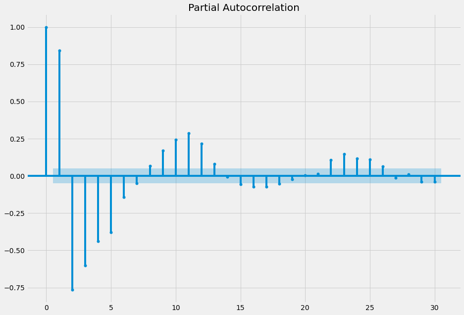

```python
# Autocorrelation partielle.
plot_pacf(dataframe_temperature, lags=30);
```

## Partie 5 : Estimation de notre modèle AR :

### Modèles AR & MA :

> Dans les séries chronologiques, les modèles d'autorégression (AR) et de moyenne mobile (MA) fournissent une description simple d'un processus en termes de deux facteurs - l'un pour l'autorégression et l'autre pour la moyenne mobile. La partie AR consiste à régresser la variable sur ses propres valeurs décalées. L'idée est que la valeur de la période précédente peut nous aider à prédire la valeur de la période actuelle. La partie MA consiste à modéliser le terme d'erreur comme une combinaison linéaire de termes d'erreur se produisant au même pas de temps et à différents moments dans le passé.

#### `Modèles autorégressifs :`

> Le modèle autorégressif (AR) correspond au moment où la valeur actuelle d'une série chronologique peut être prédite à partir des valeurs précédentes de la même série. C'est une régression utilisant sa même série, bien que décalée d'un pas de temps, appelé décalage. La valeur actuelle est une moyenne pondérée de ses valeurs passées. Le t-1 et le t-2 sont des décalages de la série chronologique y. Le terme d'erreur (bruit) est représenté par e. Les valeurs a1 et a2 sont les coefficients du modèle.

> AR(1) model: $y_{t}$ = $a_{1}$$y_{t-1}$ + $e_{t}$

> AR(2) model: $y_{t}$ = $a_{1}$$y_{t-1}$ + $a_{2}$$y_{t-2}$ + $e_{t}$

> Nous représentons généralement l'ordre du modèle comme p pour un modèle AR tel que AR(p).

#### `Modèles de moyenne mobile :`

> La moyenne mobile (MA) est un processus dans lequel la valeur actuelle d'une série chronologique, y, est définie comme une combinaison linéaire d'erreurs passées. Le terme d'erreur (bruit) est représenté par e. Le t-1 et le t-2 sont tous deux des décalages de temps sur les erreurs.

> MA(1) model: $y_{t}$ = $m_{1}$$e_{t-1}$ + $e_{t}$

> MA(2) model: $y_{t}$ = $m_{1}$$e_{t-1}$ + $m_{2}$$e_{t-2}$ + $e_{t}$

> Nous représentons généralement l'ordre du modèle comme q pour un modèle MA tel que MA(q).

#### `Modèles ARMA :`

> We can combine both Autoregressive and Moving Average models together to create an ARMA model. The time series is regressed on the previous values and the previous errors.

> ARMA(1,1) model: $y_{t}$ = $a_{1}$$y_{t-1}$ + $m_{1}$$e_{t-1}$

> Pour ARMA(p, q), p est l'ordre du processus AR et q est l'ordre du processus MA.

> Voici les bibliothèques que nous utilisons dans cette partie :

```python
import pandas as pd
from pandas.plotting import lag_plot
from pandas import read_csv
from pandas import concat
from pandas.plotting import autocorrelation_plot
from matplotlib import pyplot
from statsmodels.graphics.tsaplots import plot_acf
from statsmodels.tsa.arima_model import ARMA # Import the ARMA module from statsmodels.
```

```python
# Nous importons notre dataframe.

dataframe_temperature = pd.read_csv("Preprocessed_dataframe_temperature.csv", parse_dates=['Date'], index_col=0)
dataframe_temperature.head()
```

| Date | Value in celsius |
| --- | --- |
| 1895-01-01 | -6.333333 |
| 1895-02-01 | -8.333333 |
| 1895-03-01 | -2.277778 |
| 1895-04-01 | 7.277778 |
| 1895-05-01 | 15.333333 |

```python
values = pd.DataFrame(dataframe_temperature.values)
dataframe = concat([dataframe_temperature.shift(1), values], axis=1)
dataframe.columns = ['t-1', 't+1']
result = dataframe.corr()
print(result)
```

```
     t-1  t+1
t-1  1.0  NaN
t+1  NaN  NaN
```

> `autocorrelation_plot()` est un outil couramment utilisé pour vérifier le caractère aléatoire d'un ensemble de données. Ce caractère aléatoire est vérifié en calculant des autocorrélations pour des valeurs de données à des décalages temporels variables.

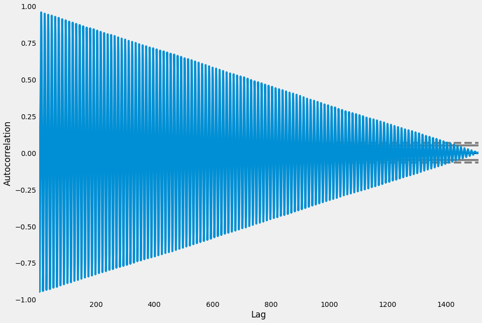

```python
# Plot the autocorrelation
autocorrelation_plot(dataframe_temperature)
pyplot.show()
```

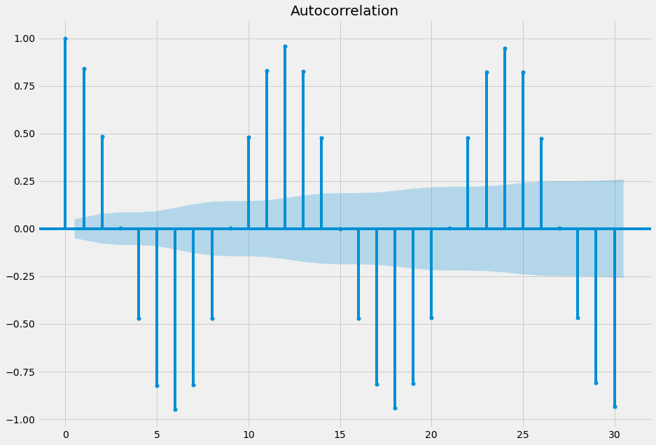

```python
# Nous traçons la fonction d'autocorrélation avec des candlesticks.
plot_acf(dataframe_temperature, lags=30)
pyplot.show()
```

# **Predictions à l'aide de AR :**

```python
from statsmodels.tsa.ar_model import AutoReg
df_train = pd.read_csv("train-data.csv", parse_dates=['Date'], index_col=0)
df_test = pd.read_csv("test-data.csv", parse_dates=['Date'], index_col=0)
ar_model = AutoReg(df_train, lags=30).fit()

#
# Print Summary
#
print(ar_model.summary())
```

```
                            AutoReg Model Results
==============================================================================
Dep. Variable:       Value in celsius   No. Observations:                 1050
Model:                    AutoReg(30)   Log Likelihood               -2098.327
Method:               Conditional MLE   S.D. of innovations              1.893
Date:                Sun, 23 Jan 2022   AIC                              1.339
Time:                        19:27:33   BIC                              1.494
Sample:                    07-01-1897   HQIC                             1.398
                         - 06-01-1982
========================================================================================
                           coef    std err          z      P>|z|      [0.025      0.975]
----------------------------------------------------------------------------------------
intercept                4.6349      0.980      4.731      0.000       2.715       6.555
Value in celsius.L1      0.2635      0.031      8.414      0.000       0.202       0.325
Value in celsius.L2      0.0302      0.032      0.932      0.351      -0.033       0.094
Value in celsius.L3     -0.0182      0.032     -0.564      0.573      -0.082       0.045
Value in celsius.L4      0.0313      0.032      0.968      0.333      -0.032       0.095
Value in celsius.L5     -0.1198      0.032     -3.710      0.000      -0.183      -0.057
Value in celsius.L6      0.0326      0.032      1.005      0.315      -0.031       0.096
Value in celsius.L7     -0.0064      0.032     -0.198      0.843      -0.070       0.057
Value in celsius.L8     -0.0578      0.032     -1.793      0.073      -0.121       0.005
Value in celsius.L9     -0.0029      0.032     -0.090      0.928      -0.066       0.060
Value in celsius.L10     0.0450      0.032      1.398      0.162      -0.018       0.108
Value in celsius.L11     0.0804      0.032      2.496      0.013       0.017       0.144
Value in celsius.L12     0.1153      0.032      3.572      0.000       0.052       0.179
Value in celsius.L13     0.0187      0.032      0.577      0.564      -0.045       0.082
Value in celsius.L14    -0.0232      0.032     -0.717      0.474      -0.087       0.040
Value in celsius.L15    -0.0144      0.032     -0.444      0.657      -0.078       0.049
Value in celsius.L16    -0.0435      0.032     -1.349      0.177      -0.107       0.020
Value in celsius.L17    -0.0544      0.032     -1.675      0.094      -0.118       0.009
Value in celsius.L18     0.0031      0.033      0.095      0.924      -0.061       0.067
Value in celsius.L19    -0.0402      0.032     -1.242      0.214      -0.104       0.023
Value in celsius.L20     0.0008      0.032      0.025      0.980      -0.062       0.064
Value in celsius.L21    -0.0507      0.032     -1.576      0.115      -0.114       0.012
Value in celsius.L22     0.0531      0.032      1.650      0.099      -0.010       0.116
Value in celsius.L23     0.0792      0.032      2.461      0.014       0.016       0.142
Value in celsius.L24     0.0908      0.032      2.815      0.005       0.028       0.154
Value in celsius.L25     0.0954      0.032      2.949      0.003       0.032       0.159
Value in celsius.L26     0.0462      0.032      1.430      0.153      -0.017       0.109
Value in celsius.L27    -0.0472      0.032     -1.462      0.144      -0.111       0.016
```

[output cut: 23 more lines]

```
AR.17           -0.6589           +0.8733j            1.0940            0.3529
AR.18           -0.4485           -0.9861j            1.0833           -0.3179
AR.19           -0.4485           +0.9861j            1.0833            0.3179
AR.20            0.5489           -0.8960j            1.0508           -0.1625
AR.21            0.5489           +0.8960j            1.0508            0.1625
AR.22           -0.2175           -1.1046j            1.1258           -0.2809
AR.23           -0.2175           +1.1046j            1.1258            0.2809
AR.24           -0.0297           -1.1325j            1.1329           -0.2542
AR.25           -0.0297           +1.1325j            1.1329            0.2542
AR.26            0.3830           -1.0987j            1.1635           -0.1966
AR.27            0.3830           +1.0987j            1.1635            0.1966
AR.28            0.2510           -1.1638j            1.1905           -0.2162
AR.29            0.2510           +1.1638j            1.1905            0.2162
AR.30           -3.9076           -0.0000j            3.9076           -0.5000
------------------------------------------------------------------------------
```

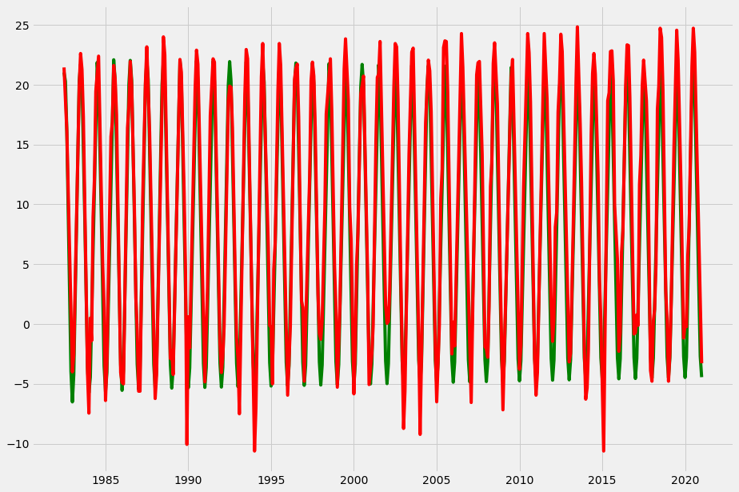

```python
#
# Make the predictions
#
pred = ar_model.predict(start=len(df_train), end=(len(df_train)+len(df_test)-1), dynamic=False)
#
# Affichage des valeurs prédites et celles de test.
#
from matplotlib import pyplot

pyplot.plot(pred,label='valeurs prédites' ,color='green') # donnéés prédites en vert
pyplot.plot(df_test, label='valeurs originales',color='red') # données de test en rouge
```

```python
# Estimation de notre modèle AR :

# On ajuste un modèle AR(1) aux premières données simulées :
mod = ARMA(dataframe_temperature, order=(1,0)) # adaptation les données à un modèle AR1
res = mod.fit()  # On utilise fit() pour estimer le modèle

# On affiche les informations récapitulatives sur l'ajustement.
print(res.summary())
```

```
                              ARMA Model Results
==============================================================================
Dep. Variable:       Value in celsius   No. Observations:                 1513
Model:                     ARMA(1, 0)   Log Likelihood               -4675.275
Method:                       css-mle   S.D. of innovations              5.316
Date:                Sun, 23 Jan 2022   AIC                           9356.550
Time:                        19:27:33   BIC                           9372.515
Sample:                    01-01-1895   HQIC                          9362.495
                         - 01-01-2021
==========================================================================================
                             coef    std err          z      P>|z|      [0.025      0.975]
------------------------------------------------------------------------------------------
const                      8.6196      0.864      9.973      0.000       6.926      10.314
ar.L1.Value in celsius     0.8424      0.014     60.768      0.000       0.815       0.870
                                    Roots
=============================================================================
                  Real          Imaginary           Modulus         Frequency
-----------------------------------------------------------------------------
AR.1            1.1870           +0.0000j            1.1870            0.0000
-----------------------------------------------------------------------------
```

```python
# Les paramètres estimés sont proches des vrais paramètres
# L1 est en retard1
# paramètres de modèle ajustés
print(res.params)
```

```
const                     8.619596
ar.L1.Value in celsius    0.842425
dtype: float64
```

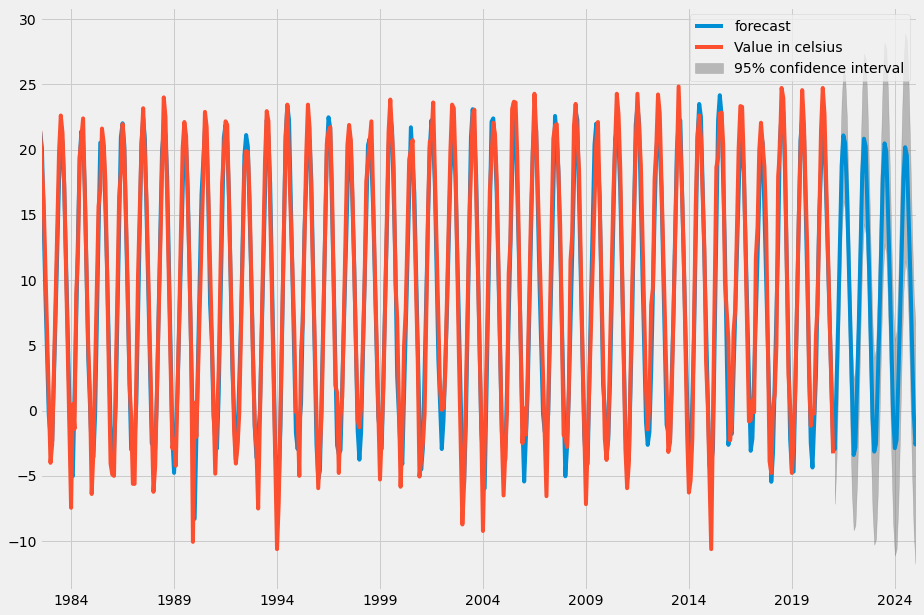

```python
# Nous prévoyons le premier modèle AR(1)
mod = ARMA(dataframe_temperature, order=(10,0))
res = mod.fit()


# Nous commençons la prévision 10 points de données avant la fin de la série de points à ,
# et terminons la prévision 10 points de données après la fin de la série au point.
res.plot_predict(start='1982-07-01', end='2025-01-05')
pyplot.show()
```

## ARIMA :

```python
from statsmodels.tsa.arima_model import ARIMA
import pandas as pd
from tqdm.notebook import tqdm
import warnings

#On déclare un dictionnaire pour regruper les predictions
predictions={}
warnings.filterwarnings("ignore")
df_train = pd.read_csv("train-data.csv", parse_dates=['Date'], index_col=0)
df_test = pd.read_csv("test-data.csv", parse_dates=['Date'], index_col=0)
index = len(df_train)
yhat = list()

for t in tqdm(range(len(df_test))):
    temp_train = dataframe_temperature[:len(df_train)+t]
    model = ARIMA(temp_train, order=(12, 0, 0))
    model_fit = model.fit()
    predictions = model_fit.predict(
        start=len(temp_train), end=len(temp_train), dynamic=False)
    yhat = yhat + [predictions]

yhat = pd.concat(yhat)
predictions['ARIMA'] = yhat.values
```

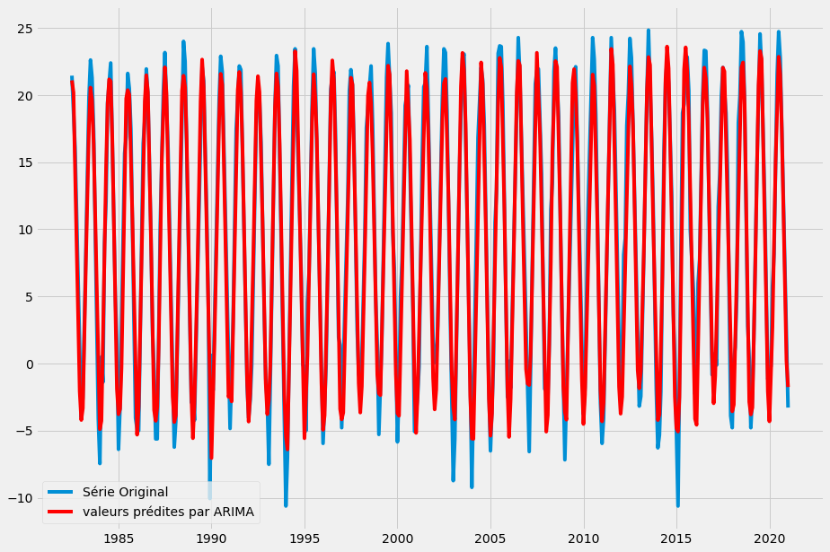

```python
plt.plot(df_test, label='Série Original')
plt.plot(yhat, color='red', label='valeurs prédites par ARIMA')
plt.legend()
```

## SARIMAX :

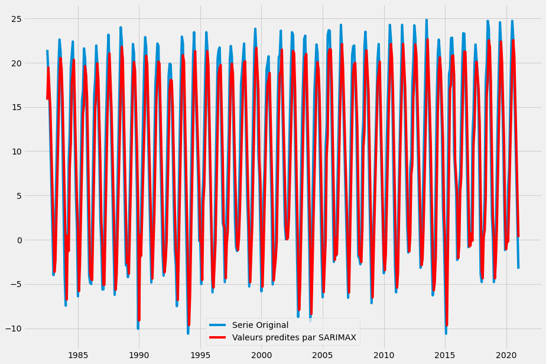

```python
import pandas as pd
import numpy as np
import matplotlib.pyplot as plt
import statsmodels as sm
from pylab import rcParams
from statsmodels.tsa.seasonal import seasonal_decompose
from statsmodels.graphics.tsaplots import plot_acf, plot_pacf
from statsmodels.tsa.stattools import adfuller
from statsmodels.tsa.arima.model import ARIMA
from statsmodels.tsa.ar_model import AutoReg
import statsmodels.api as sm
import warnings
from sklearn.linear_model import LinearRegression
import itertools
from tqdm import tqdm
import warnings
p = d = q = range(0, 2)

# Generate all different combinations of p, q and q triplets
pdq = list(itertools.product(p, d, q))

# Generate all different combinations of seasonal p, q and q triplets
seasonal_pdq = [(x[0], x[1], x[2], 12) for x in list(itertools.product(p, d, q))]

df_train = pd.read_csv("train-data.csv", parse_dates=['Date'], index_col=0)
df_test = pd.read_csv("test-data.csv", parse_dates=['Date'], index_col=0)

for param in pdq:
    for param_seasonal in seasonal_pdq:
        try:
            mod = sm.tsa.statespace.SARIMAX( dataframe_temperature,
                                            order=param,
                                            seasonal_order=param_seasonal,
                                            enforce_stationarity=False,
                                            enforce_invertibility=False)

            results = mod.fit()
        except:
            continue

index = len(df_train)
yhat = list()
for t in tqdm(range(len(df_test))):
    temp_train =  dataframe_temperature[:len(df_train)+t]
    model = sm.tsa.statespace.SARIMAX(temp_train, order=(
        1, 0, 0), seasonal_order=(0, 0, 0, 3))
    model_fit = model.fit(disp=False)
    predictions = model_fit.predict(
        start=len(temp_train), end=len(temp_train), dynamic=False)
    yhat = yhat + [predictions]

yhat = pd.concat(yhat)
predictions['SARIMAX'] = yhat.values

plt.plot(df_test, label='Serie Original')
plt.plot(yhat, color='red', label='Valeurs predites par SARIMAX')
plt.legend()
```

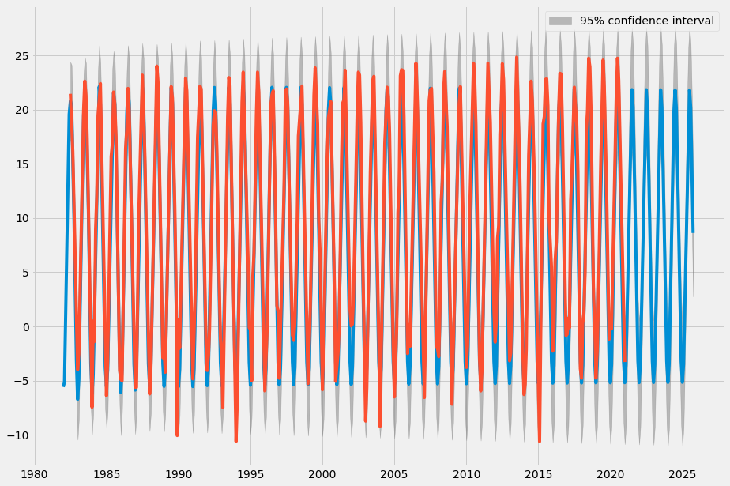

```python
from statsmodels.tsa.ar_model import AutoReg
mod = AutoReg(df_train, lags=50) # adaptation les données à un modèle AR1
res = mod.fit()  # On utilise fit() pour estimer le modèle

# On affiche les informations récapitulatives sur l'ajustement.
res.plot_predict(start='1982-01-01', end='2025-10-01')
plt.plot(df_test, label='Serie Original')
pyplot.show()
```

# Conclusion :

> En guise de conclusion, l'étude de cette série temporelle nous a permis de s'approcher et manipuler des notions abstraites que nous avons vu dans le cours. a savoir la préparation des données , la décomposition de la série, l'étude de chaque composante, le test de stationnarité , le choix du degré du modèle ainsi que l'entrainement de ce dernier et finalement les prévision des valeurs futures. Cette étude a été réalisée à l'aide des outils mathématiques fourni dans Python ce qui rend cette manipulation facile. Il est important de noter qu'il est important de faire une analyse approfondie de notre série pour détecter la stationnarité ou les saisonnalités spéciales qui peuvent nous obliger à appliquer une transformation à la série et détermineront probablement notre sélection de modèle. La sélection à l'aveugle des modèles ne devrait jamais être le cas et nous devrions toujours viser une bonne compréhension de notre série.